# process

eve-ning

4/20/2019

# Taxation in Singapore

[Source](https://data.gov.sg/dataset/taxable-individuals-by-assessable-income-group-annual?view_id=9ba609ea-c65f-4630-a48e-4c562b5337bc&resource_id=65913425-8a0d-47ca-b9f7-569bca3ac688)

Source Notes:

- ‘Assessable Income refers to the total income of an individual less allowable deductions such as business expenses, employment expenses and donations.’
- ‘Chargeable Income of an individual is his/her assessable income less the personal reliefs allowed.’
- ‘Net Tax Assessed is the net tax payable or repayable by an individual after taking into account allowable tax credits, tax remission, tax rebates and tax deducted at source.’
- ‘Non-Tax Resident refers to an individual who has worked in Singapore for less than 183 days in the preceding year of the Year of Assessment.’

## Columns

- **Year of Assessment**: When the taxation assessment was conducted
- **Assessed Income Group**: Yearly income in SGD grouping
- **Type of Resident**: Non-Tax/Tax Resident, *refer to Source Notes*
- **Number of Taxpayers**
- **Assessable Income**: S$ Thousand
- **Chargeable Income**: S$ Thousand
- **Net Tax Assessed**: S$ Thousand

### Assessable Income

**Assessable Income**, as defined by the source, is the total **yearly** income, subtract allowance deductions such as business expenses, employment expenses & donations.

[Read more here (under Expenses and Donations)](https://www.iras.gov.sg/irashome/Individuals/Locals/Working-Out-Your-Taxes/Deductions-for-Individuals--Reliefs--Expenses--Donations-/)

In other words:

$$Income_{Assessable} = Income_{Yearly} - (expenses + donations)$$

### Chargeable Income

**Chargeable Income**, as defined by the source, is **Assessable Income** minus personal reliefs

[Read more here (under Reliefs)](https://www.iras.gov.sg/irashome/Individuals/Locals/Working-Out-Your-Taxes/Deductions-for-Individuals--Reliefs--Expenses--Donations-/)

In other words:

$$Income_{Chargeable} = Income_{Assessable} - reliefs = Income_{Yearly} - (expenses + donations + reliefs)$$

### Net Tax

**Net Tax**, as defined by the source, is the total Tax paid which after accounting into tax credits, tax remission, tax rebates, tax deducted at source

### Non-Tax Resident

[Read more here](https://www.iras.gov.sg/irashome/Individuals/Foreigners/Working-out-your-taxes/Tax-Rates-for-Resident-and-Non-Residents/)

## Goals

We can look at the surface trends of this data provided, such as: - How has the economy grown over the years? - Has the disparity between the income groups increased, what is the trend? - How is tax related to the income groups, is it fair?

# Number of Taxpayers By Income Groups

Taxed amounts aside, we can analyse how many people are in specific **income groups** by looking at the data.

We will simply drop these data into a ggplot where we group them by their income groups.

[figure not shown]

```r
knitr::kable(tax.resident.grw.wide)
```

| assessed_income_group | 2004 | 2005 | 2006 | 2007 | 2008 | 2009 | 2010 | 2011 | 2012 | 2013 | 2014 | 2015 | 2016 | 2017 |
| --- | --- | --- | --- | --- | --- | --- | --- | --- | --- | --- | --- | --- | --- | --- |
| 20,000 & below | 0% | 0.0% | 0.0% | 0.0% | 0.0% | 0.0% | 0.0% | 0.0% | 0.0% | 0.0% | 0.0% | 0.0% | 0.00% | 0.0% |
| 20,001 - 25,000 | 0% | -20.1% | 11.3% | 11.6% | 20.5% | 31.6% | 12.7% | 8.6% | 25.4% | 16.2% | 8.2% | -3.3% | -0.20% | 4.4% |
| 25,001 - 30,000 | 0% | -1.4% | 1.0% | 6.2% | 10.5% | 17.0% | 8.6% | 13.9% | 13.4% | 7.4% | 12.3% | 5.3% | -1.20% | -1.3% |
| 30,001 - 40,000 | 0% | 2.4% | 2.0% | 6.6% | 6.6% | 1.7% | 6.2% | 9.2% | 10.8% | 7.0% | 6.6% | 6.0% | 5.30% | 3.4% |
| 40,001 - 50,000 | 0% | 1.3% | 3.5% | 10.7% | 11.1% | 3.4% | 1.9% | 8.2% | 8.1% | 9.7% | 8.1% | 6.0% | 2.40% | 2.3% |
| 50,001 - 60,000 | 0% | 3.5% | 7.3% | 10.1% | 13.0% | 8.9% | 0.8% | 7.6% | 10.4% | 7.8% | 9.4% | 8.7% | 5.00% | 2.0% |
| 60,001 - 70,000 | 0% | 2.8% | 6.1% | 11.3% | 15.0% | 9.5% | -1.5% | 11.4% | 11.1% | 9.1% | 7.4% | 7.9% | 5.50% | 4.0% |
| 70,001 - 80,000 | 0% | 3.8% | 6.3% | 11.4% | 13.6% | 11.2% | -0.5% | 12.6% | 11.0% | 7.8% | 8.3% | 7.6% | 6.60% | 4.3% |
| 80,001 - 100,000 | 0% | 6.2% | 6.7% | 13.9% | 18.5% | 10.9% | -0.1% | 12.1% | 11.9% | 7.6% | 10.8% | 6.5% | 7.60% | 3.7% |
| 100,001 - 150,000 | 0% | 6.1% | 8.2% | 15.5% | 19.6% | 14.8% | 2.4% | 14.3% | 13.1% | 8.2% | 12.3% | 6.6% | 7.70% | 4.1% |
| 150,001 - 200,000 | 0% | 3.7% | 13.0% | 16.0% | 21.3% | 16.0% | 0.1% | 13.9% | 16.7% | 7.4% | 15.2% | 8.3% | 8.00% | 6.6% |
| 200,001 - 300,000 | 0% | 6.2% | 11.3% | 14.8% | 23.6% | 15.3% | 1.8% | 13.0% | 14.2% | 8.7% | 10.7% | 9.1% | 7.50% | 4.6% |
| 300,001 - 400,000 | 0% | 7.5% | 12.5% | 18.0% | 25.9% | 17.9% | 1.8% | 13.0% | 13.5% | 6.8% | 7.7% | 8.7% | 6.40% | 5.2% |
| 400,001 - 500,000 | 0% | 9.7% | 13.6% | 16.3% | 29.8% | 15.2% | 1.0% | 13.5% | 16.4% | 8.2% | 7.9% | 12.2% | 5.00% | 4.5% |
| 500,001 - 1,000,000 | 0% | 11.1% | 21.3% | 20.3% | 28.6% | 9.6% | -0.9% | 15.5% | 16.5% | 6.1% | 7.6% | 13.6% | 5.90% | 2.0% |
| 1,000,001 & above | 0% | 17.6% | 21.2% | 30.4% | 39.4% | -5.5% | -18.1% | 31.6% | 9.0% | 0.3% | 7.7% | 12.8% | 6.90% | -5.2% |

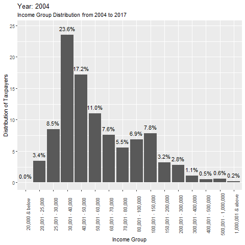

## Observations

### Largest Income Group

$$[30k_{SGD}, 40k_{SGD}]/y \approx [2.5k_{SGD}, 3.3k_{SGD}]/m$$
It has always been the biggest group of taxpayers and it’ll most likely stay that way for years to come.

### Declining Income Groups

*barring the very small income groups in which we will discuss later*
$$[20k_{SGD}, 25k_{SGD}]/y \approx [1.7k_{SGD}, 2.1k_{SGD}]/m$$
$$[25k_{SGD}, 30k_{SGD}]/y \approx [2.1k_{SGD}, 2.5k_{SGD}]/m$$

### Global Financial Crisis of (around) 2008

An interesting observation is this would be how Singapore is affected during the the [Financial Crisis](http://eresources.nlb.gov.sg/history/events/3cacf256-82cc-4776-b7f8-83757723b502).

- Most Income Groups stagnated around that period or declined except those $< 30k_{SGD}/y$ in which increased in population readily.

## Forecasting

### Future Largest Income Group

I foresee that the dominating future income group would fall under $[30k_{SGD}, 40k_{SGD}]/y$, falling slightly below 1/5 of the population. A few reasons for the prediction:

- Between this and its following group, $[40k_{SGD}, 50k_{SGD}]/y$, the gap has **widened**, especially in the past few years.
- The two groups $[20k_{SGD}, 25k_{SGD}]/y + [25k_{SGD}, 30k_{SGD}]/y$ has decreased in population, shifting up in income groups, likely to $[30k_{SGD}, 40k_{SGD}]$